# Data Analytics and Visualizations in R - Exercises

## 5.19 All about aesthetics, part 3

Now that you’ve got some practice with incrementally building up plots, you can try to do it from scratch! The mtcars dataset is pre-loaded in the workspace.

### 5.19.1 Instructions

Use ggplot() to create a basic scatter plot. Inside aes(), map wt onto x and mpg onto y. Typically, you would say “mpg described by wt” or “mpg vs wt”, but in aes(), it’s x first, y second. Use geom_point() to make three scatter plots:

cyl on size cyl on alpha cyl on shape Try this last variant:

cyl on label. In order to correctly show the test (i.e. label), use geom_text().

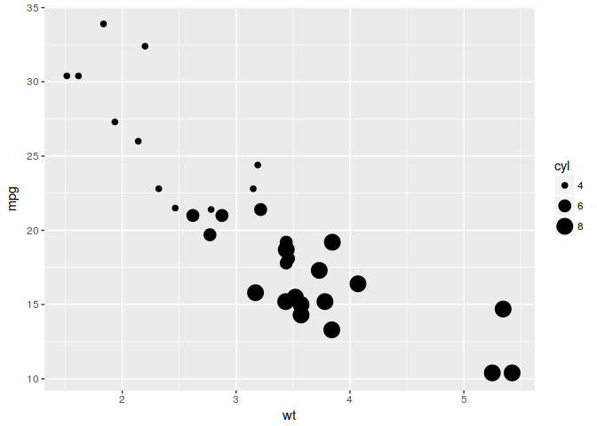

```r
# Map cyl to size
ggplot(mtcars, aes(x = wt, y = mpg, size=cyl)) +
  geom_point()
```

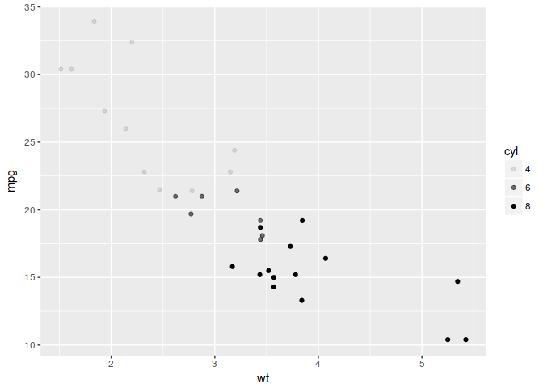

```r
# Map cyl to alpha
ggplot(mtcars, aes(x = wt, y = mpg, alpha=cyl)) +
  geom_point()
```

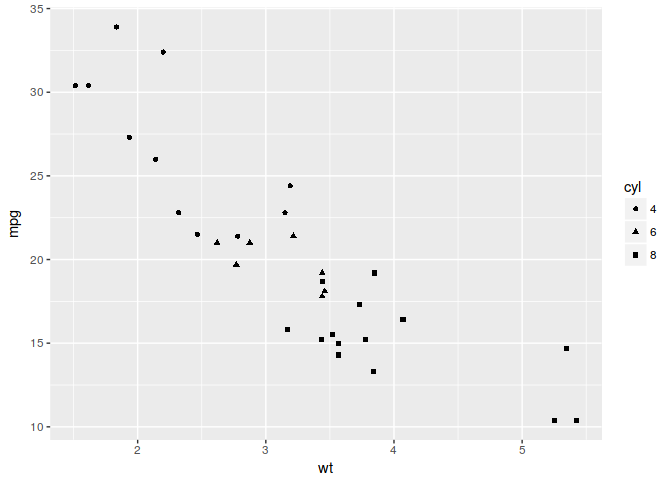

```r
# Map cyl to shape
ggplot(mtcars, aes(x = wt, y = mpg, shape=cyl)) +
  geom_point()
```

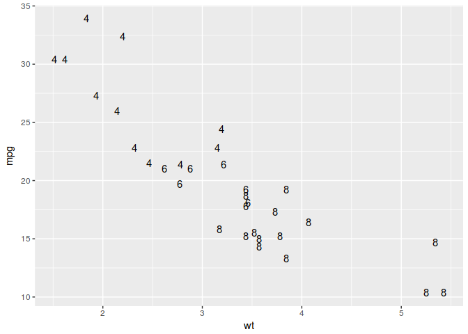

```r
# Map cyl to label
ggplot(mtcars, aes(x = wt, y = mpg, label=cyl)) +
  geom_text()
```

```r
# Nice! Which aesthetic do you think is the clearest for categorical data?
```

## 5.20 All about attributes, part 1

In the video you saw that you can use all the aesthetics as attributes. Let’s see how this works with the aesthetics you used in the previous exercises: x, y, color, fill, size, alpha, label and shape.

This time you’ll use these arguments to set attributes of the plot, not aesthetics. However, there are some pitfalls you’ll have to watch out for: these attributes can overwrite the aesthetics of your plot!

A word about shapes: In the exercise “All about aesthetics, part 2”, you saw that shape = 21 results in a point that has a fill and an outline. Shapes in R can have a value from 1-25. Shapes 1-20 can only accept a color aesthetic, but shapes 21-25 have both a color and a fill aesthetic. See the pch argument in par() for further discussion.

A word about hexadecimal colours: Hexadecimal, literally “related to 16”, is a base-16 alphanumeric counting system. Individual values come from the ranges 0-9 and A-F. This means there are 256 possible two-digit values (i.e. 00 - FF). Hexadecimal colours use this system to specify a six-digit code for Red, Green and Blue values (“#RRGGBB”) of a colour (i.e. Pure blue: “#0000FF”, black: “#000000”, white: “#FFFFFF”). R can accept hex codes as valid colours.

### 5.20.1 Instructions

1 - You will continue to work with mtcars. Use ggplot() to create a basic scatter plot: map wt onto x, mpg onto y and cyl onto color. 2 - Overwrite the color of the points inside geom_point() to my_color. Notice how this cancels out the colors given to the points by the number of cylinders! 3 - Starting with plot 2, map cyl to fill instead of col and set the attributes size to 10, shape to 23 and color to my_color inside geom_point().

```r
# Define a hexadecimal color
my_color <- "#4ABEFF"

# 1 - First scatter plot, with col aesthetic:
ggplot(mtcars, aes(x = wt, y=mpg, col=cyl)) +
  geom_point()
```

[output not shown]

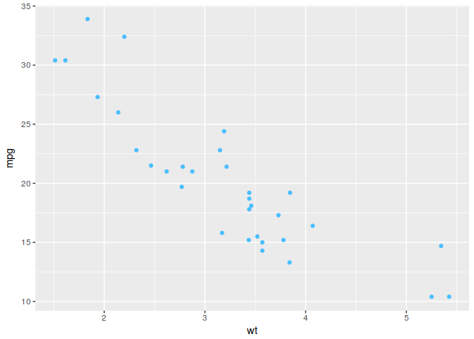

```r
# 2 - Plot 1, but set col attributes in geom layer:
ggplot(mtcars, aes(x=wt, y=mpg, col=cyl)) +
  geom_point(color=my_color)
```

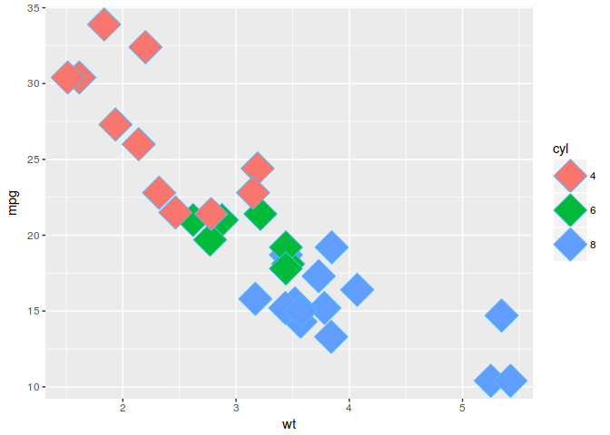

```r
# 3 - Plot 2, with fill instead of col aesthetic, plut shape and size attributes in geom layer.
ggplot(mtcars, aes(x=wt, y=mpg, fill=cyl)) +
  geom_point(size=10, shape=23, color=my_color)
```

```r
# Hunky-dory hex specs! Notice that if an aesthetic and an attribute are set
# with the same argument, the attribute takes precedence. Once again, you see
# that the attribute needs to match the shape and geom, the fill aesthetic
# (or attribute) will only work with certain shapes.
```

## 5.21 All about attributes, part 2

In the videos you saw that you can use all the aesthetics as attributes. Let’s see how this works with the aesthetics you used in the previous exercises: x, y, color, fill, size, alpha, label and shape.

In this exercise you will set all kinds of attributes of the points!

You will continue to work with mtcars.

### 5.21.1 Instructions

Add to the first command: draw points with alpha set to 0.5. Add to the second command: draw points of shape 24 in the color yellow. Add to the third command: draw text with label rownames(mtcars) in the color red. Don’t use geom_point() here! You should get a scatter plot with the names of the cars instead of points. Note: Remember to specify characters with quotation marks (“yellow”, not yellow).

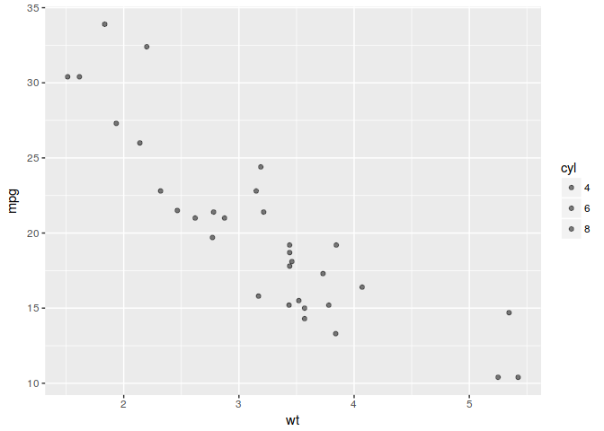

```r
# Expand to draw points with alpha 0.5
ggplot(mtcars, aes(x = wt, y = mpg, fill = cyl)) +
  geom_point(alpha=0.5)
```

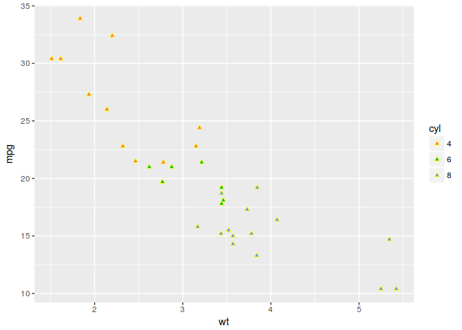

```r
# Expand to draw points with shape 24 and color yellow
ggplot(mtcars, aes(x = wt, y = mpg, fill = cyl)) +
  geom_point(shape=24, color="yellow")
```

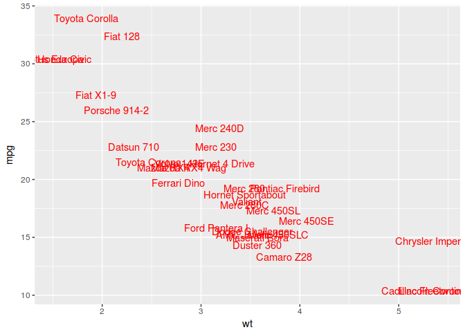

```r
# Expand to draw text with label rownames(mtcars) and color red
ggplot(mtcars, aes(x = wt, y = mpg, fill = cyl)) +
  geom_text(label=rownames(mtcars), color="red")
```

```r
# Awesome attribute assembling! Notice how ggplot2 lets you control these
# different attributes.
```

## 5.22 Going all out

In this exercise, you will gradually add more aesthetics layers to the plot. You’re still working with the mtcars dataset, but this time you’re using more features of the cars. For completeness, here is a list of all the features of the observations in mtcars:

mpg – Miles/(US) gallon cyl – Number of cylinders disp – Displacement (cu.in.) hp – Gross horsepower drat – Rear axle ratio wt – Weight (lb/1000) qsec – 1/4 mile time vs – V/S engine. am – Transmission (0 = automatic, 1 = manual) gear – Number of forward gears carb – Number of carburetors

Notice that adding more aesthetics to your plot is not always a good idea. Adding aesthetic mappings to a plot will increase its complexity, and thus decrease its readability.

### 5.22.1 Instructions

Note: In this chapter you saw aesthetics and attributes. Variables in a data frame are mapped to aesthetics in aes(). (e.g. aes(col = cyl)) within ggplot(). Visual elements are set by attributes in specific geom layers (geom_point(col = “red”)). Don’t confuse these two things - here you’re focusing on aesthetic mappings.

Draw a scatter plot of mtcars with mpg on the x-axis, qsec on the y-axis and factor(cyl) as colors. Expand the previous plot to include factor(am) as the shape of the points. Expand the previous plot to include the ratio of horsepower to weight (i.e. (hp/wt)) as the size of the points.

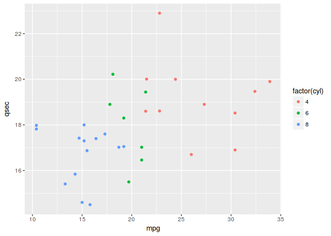

```r
# Map mpg onto x, qsec onto y and factor(cyl) onto col
ggplot(mtcars, aes(x=mpg, y=qsec, col=factor(cyl))) +
  geom_point()
```

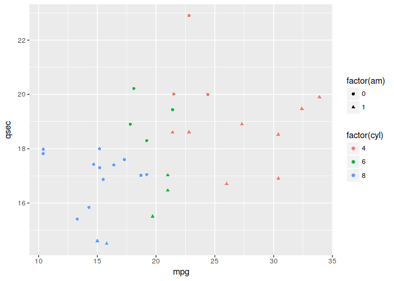

```r
# Add mapping: factor(am) onto shape
ggplot(mtcars, aes(x=mpg, y=qsec, col=factor(cyl), shape=factor(am))) +
  geom_point()
```

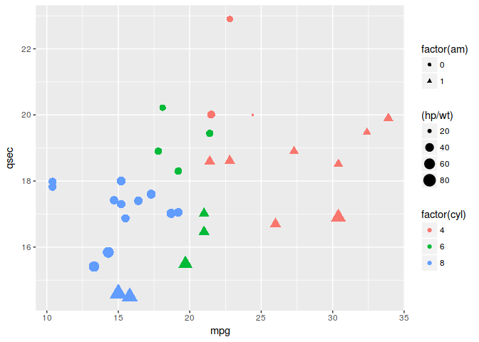

```r
# Add mapping: (hp/wt) onto size
ggplot(mtcars, aes(x=mpg, y=qsec, col=factor(cyl), shape=factor(am), size=(hp/wt))) +
  geom_point()
```

```r
# That's a pretty slick plot! Between the x and y dimensions, the color, shape,
# and size of the points, your plot displays five dimensions of the dataset!
```

## 5.23 Position

You saw how jittering worked in the video, but bar plots suffer from their own issues of overplotting, as you’ll see here. Use the “stack”, “fill” and “dodge” positions to reproduce the plot in the viewer.

The ggplot2 base layers (data and aesthetics) have already been coded; they’re stored in a variable cyl.am. It looks like this:

`cyl.am <- ggplot(mtcars, aes(x = factor(cyl), fill = factor(am)))`

### 5.23.1 Instructions

Add a geom_bar() call to cyl.am. By default, the position will be set to “stack”. Fill in the second ggplot command. Explicitly set position to “fill” inside geom_bar(). Fill in the third ggplot command. Set position to “dodge”. The position = “dodge” version seems most appropriate. Finish off the fourth ggplot command by completing the three scale_ functions: scale_x_discrete() takes as its only argument the x-axis label: “Cylinders”. scale_y_continuous() takes as its only argument the y-axis label: “Number”. scale_fill_manual() fixes the legend. The first argument is the title of the legend: “Transmission”. Next, values and labels are set to predefined values for you. These are the colors and the labels in the legend.

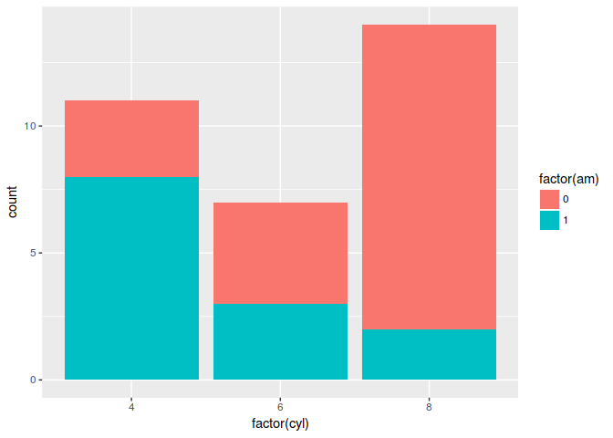

```r
cyl.am <- ggplot(mtcars, aes(x = factor(cyl), fill = factor(am)))
# The base layer, cyl.am, is available for you
# Add geom (position = "stack" by default)
cyl.am + geom_bar(position="stack")
```

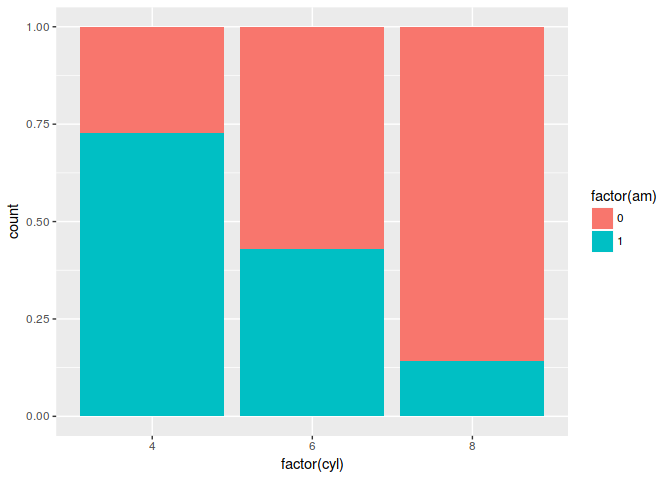

```r
# Fill - show proportion
cyl.am +
  geom_bar(position = "fill")
```

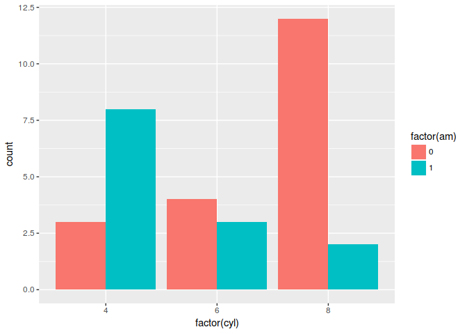

```r
# Dodging - principles of similarity and proximity
cyl.am +
  geom_bar(position = "dodge")
```

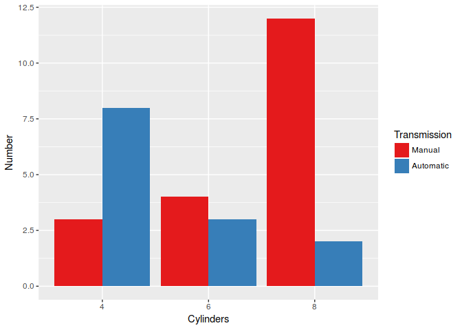

```r
# Clean up the axes with scale_ functions
val = c("#E41A1C", "#377EB8")
lab = c("Manual", "Automatic")
cyl.am +
  geom_bar(position = "dodge") +
  scale_x_discrete("Cylinders") +
  scale_y_continuous("Number") +
  scale_fill_manual("Transmission",
                    values = val,
                    labels = lab)
```

```r
# Premier positioning! Choosing the right position argument is an important part
# of making a good plot.
```

## 5.24 Setting a dummy aesthetic

In the last chapter you saw that all the visible aesthetics can serve as attributes and aesthetics, but I very conveniently left out x and y. That’s because although you can make univariate plots (such as histograms, which you’ll get to in the next chapter), a y-axis will always be provided, even if you didn’t ask for it.

You can get the same thing in ggplot2, but it’s a bit more cumbersome. The only reason you’d really want to do this is if you were making many plots and you wanted them to be in the same style, or you wanted to take advantage of an aesthetic mapping (e.g. colour).

### 5.24.1 Instructions

Try to run ggplot(mtcars, aes(x = mpg)) + geom_point() in the console. x is only one of the two essential aesthetics for geom_point(), which is why you get an error message. 1 - To fix this, map a value, e.g. 0, instead of a variable, onto y. Use geom_jitter() to avoid having all the points on a horizontal line. 2 - To make everything look nicer, copy & paste the code for plot 1 and change the limits of the y axis using the appropriate scale_y_…() function. Set the limits argument to c(-2, 2).

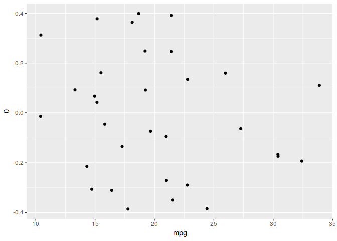

```r
# 1 - Create jittered plot of mtcars, mpg onto x, 0 onto y
ggplot(mtcars, aes(x = mpg, y = 0)) +
  geom_jitter()
```

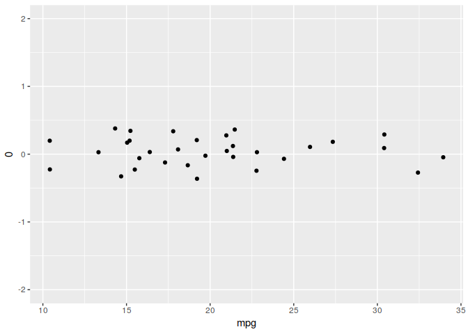

```r
# 2 - Add function to change y axis limits
ggplot(mtcars, aes(x = mpg, y = 0)) +
  geom_jitter() +
  scale_y_continuous(limits = c(-2,2))
```

```r
# Great work! The best way to make your plot depends on a lot of different
# factors and sometimes ggplot2 might not be the best choice.
```

## 5.25 Overplotting 1 - Point shape and transparency

In the previous section you saw that there are lots of ways to use aesthetics. Perhaps too many, because although they are possible, they are not all recommended. Let’s take a look at what works and what doesn’t.

So far you’ve focused on scatter plots since they are intuitive, easily understood and very common. A major consideration in any scatter plot is dealing with overplotting. You’ll encounter this topic again in the geometries layer, but you can already make some adjustments here.

You’ll have to deal with overplotting when you have:

Large datasets, Imprecise data and so points are not clearly separated on your plot (you saw this in the video with the iris dataset), Interval data (i.e. data appears at fixed values), or Aligned data values on a single axis. One very common technique that I’d recommend to always use when you have solid shapes it to use alpha blending (i.e. adding transparency). An alternative is to use hollow shapes. These are adjustments to make before even worrying about positioning. This addresses the first point as above, which you’ll see again in the next exercise.

### 5.25.1 Instructions

Begin by making a basic scatter plot of mpg (y) vs. wt (x), map cyl to color and make the size = 4. cyl has already been converted to a factor variable for you. Modify the above plot to set shape to 1. This allows for hollow circles. Modify the first plot to set alpha to 0.6.

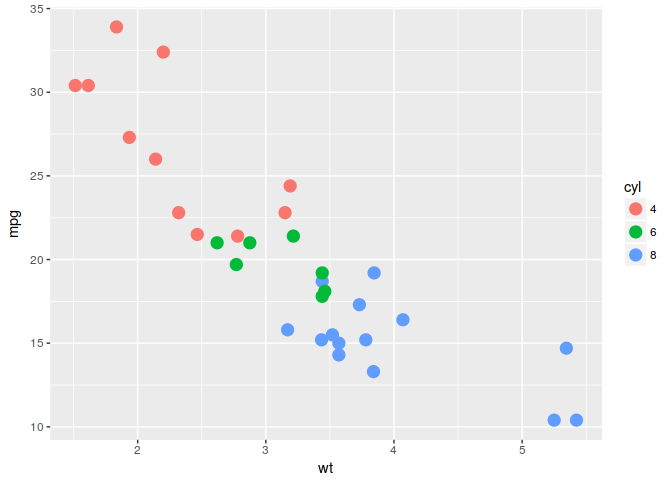

```r
# Basic scatter plot: wt on x-axis and mpg on y-axis; map cyl to col
ggplot(mtcars, aes(x=wt, y=mpg, col=cyl)) +
  geom_point(size=4)
```

```r
# Hollow circles - an improvement
ggplot(mtcars, aes(x=wt, y=mpg, col=cyl)) +
  geom_point(size=4, shape=1)
```

[output not shown]

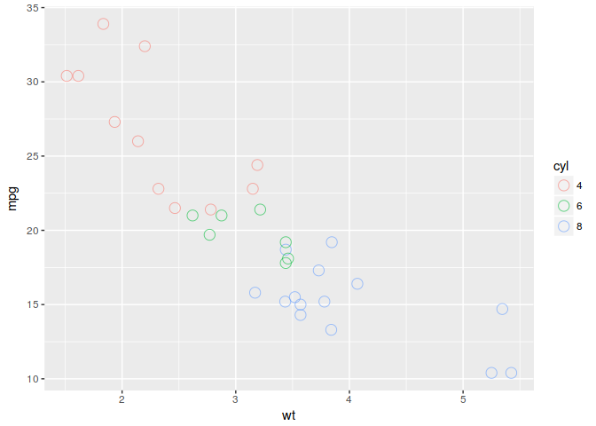

```r
# Add transparency - very nice
ggplot(mtcars, aes(x=wt, y=mpg, col=cyl)) +
  geom_point(size=4, shape=1, alpha=0.6)
```

```r
# Good job! By now you should understand why solid shapes are not really useful.
```

## 5.26 Overplotting 2 - alpha with large datasets

1. Large datasets.
2. Aligned data values on a single axis

### 5.26.1 Instructions

The diamonds data frame is available in the ggplot2() package. Begin by making a basic scatter plot of price (y) vs. carat (x) and map clarity onto color. Copy the above functions and set the alpha to 0.5. This is a good start to dealing with the large dataset. Align all the diamonds within a clarity class, by plotting carat (y) vs. clarity (x). Map price onto color. alpha should still be 0.5. In the previous plot, all the individual values line up on a single axis within each clarity category, so you have not overcome overplotting. Modify the above plot to use the position = “jitter” inside geom_point().

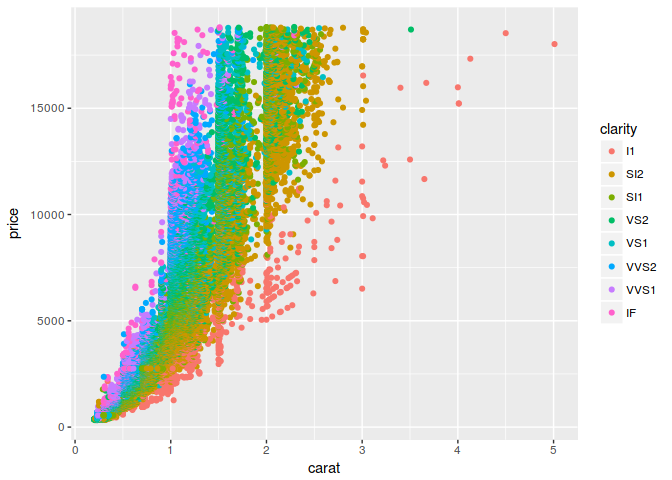

```r
# Scatter plot: carat (x), price (y), clarity (color)
ggplot(diamonds, aes(x=carat, y=price, col=clarity)) +
  geom_point()
```

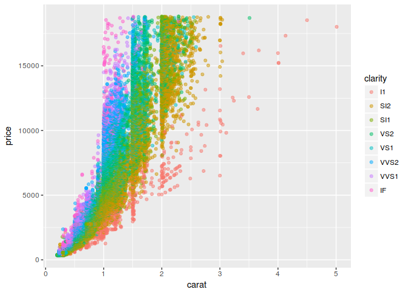

```r
# Adjust for overplotting
ggplot(diamonds, aes(x=carat, y=price, col=clarity)) +
  geom_point(alpha=0.5)
```

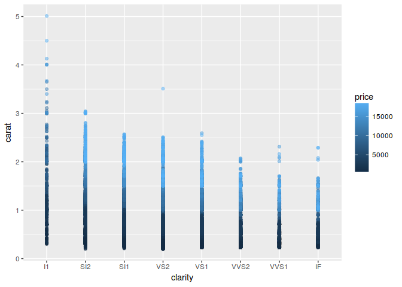

```r
# Scatter plot: clarity (x), carat (y), price (color)
ggplot(diamonds, aes(x=clarity, y=carat, col=price)) +
  geom_point(alpha=0.5)
```

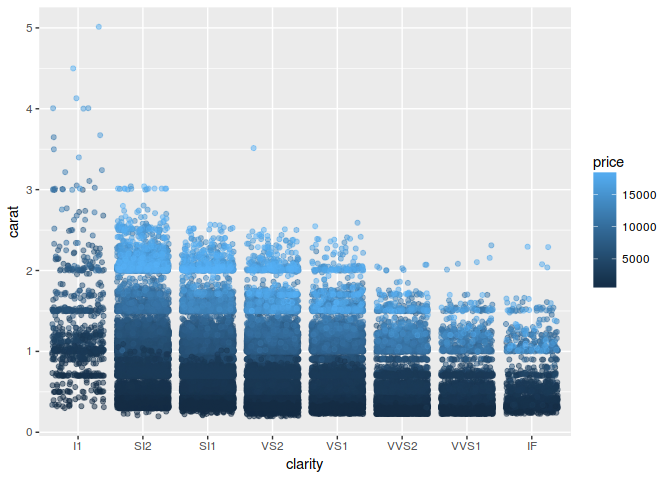

```r
# Dot plot with jittering
ggplot(diamonds, aes(x=clarity, y=carat, col=price)) +
  geom_point(alpha=0.5, position="jitter")
```

```r
# Tantalizing transparency! These are some simple ways of dealing with large
# datasets, but you'll encounter more ideas in the geom chapter and in the
# advanced course on ggplot2 when you look at atypical geoms.

# You have finished the chapter "Aesthetics"!
```